# Application of the scp pipeline on adult cardiomyocytes data

Sven Berres, Louise Buur, Laurent Gatto, Enrico Massignani, Sam van Puyenbroeck, Christophe Vanderaa and Hannah Voß

Medical Bioinfomratics, University Bochum, Germany  
Bioinformatics Research Group, University of Applied Sciences Upper Austria, Austria  
de Duve Institute, UCLouvain, Belgium  
CompOmics, UGent, Belgium  
statOmics, UGent, Belgium  
Immunoproteomics (AG Shevchuck), University Clinic Essen, Germany

6 February 2025

#### Abstract

Application of the `scp` pipeline on adult cardiomyocytes data from Ai et al. 2025. This vignette is distributed under a CC BY-SA license.

#### Package

QFeatures 1.17.2

# 1 Introduction

In this vignette, we will reanalyse single-cell proteomics data from (Ai et al. 2025).

## 1.1 Motivation of the original paper

iPSC-derived cardiomyocytes (iCMs) have been proposed as a model to study cardiovascular diseases. However, this requires that iCMs display the same biological features as adult cardiomyocytes (aCMs). The authors of the manuscript used MS-based single-cell proteomics to analyze metabolic changes in iPSCs during differentiation process and to compare the resulting iCMs to freshly-isolated aCMs.

Here, we will focus on the analysis of the aCMs data.

## 1.2 Data origin

Single cardiomyocytes were isolated from 3 human hearts using enzymatic digestion isolation technique.

Cells were isolated from 4 regions of the heart, labelled **LVepi** (left ventricle, epi-myocardium), **LVendo** (left ventricle, endo-myocardium), **LVmid** (left ventricle, mid-myocardium), and **RV** (right ventricle).

Single cell proteomes were analyzed in a label-free approach. MS data was acquired in data-independent mode (DIA-MS).

Data were analyzed with DIA-NN 1.8.1 and DIA-NN 1.8.2. The DIA-NN reports were downloaded from MassIVE (MSV000094438).

#### 1.2.0.1 Packages

The following packages were used to compile this vignette.

```r
library(scp)
library(tidyverse)
library(patchwork)
```

# 2 Data prepartion and processing

We can now read in the results file from DIA-NN. We use the file `report.tsv` file generate by DIA-NN (renamed `aCMs_report.zip` below).

```r
acmsTab <- read_tsv("./data/aCMs_report.zip")
```

We can use the `readSCPfromDIANN` to have an initial look at the data.

```r
acms <- readSCPfromDIANN(acmsTab)
acms
```

Doing this, we already create a `QFeatures` object, but we want extract additional metadata from the file names.

We want to extract: - File name - Sample name - Acquisition date - Subject number - Location in the heart from which each cell was extracted (Lvendo, Lvepi, Lvmid, RV, sytox) - Position in the 384 well plate - Position (BA18, …)

We see that `acms` object contains 299 assays (which means that 299 cells were analysed).

Our goal is then to create a data frame with 299 rows, one for each cell, with the information defined above as the columns.

```r
## Extracting file name, sample name, date, subject, well position and
## position
tab <- tibble(File.Name = unique(acmsTab[[1]])) |>
  mutate(Sample = sub("^.+CM_PROJECT\\\\", "", File.Name)) |>
  mutate(Sample = sub("\\\\", "_", Sample)) |>
  mutate(Date = ymd(as.integer(substring(Sample, 1, 6)))) |>
  mutate(Subject = sub("^.+_(Subject[0-9])_.+$", "\\1", Sample)) |>
  mutate(PlateWell = sub("^.+_([A-Z][0-9]+)_.+$", "\\1", Sample)) |>
  mutate(Position = sub("^.+_([A-Z]+[0-9]+)_1_[0-9]+\\.d$", "\\1", Sample))

## Getting the plate letters
tab$PlateLetter <- substring(tab$PlateWell, 1, 1)

## Extracting the heart locations
tab$HeartLocation <- NA
ExpectedLocations <- c("Lvendo", "Lvepi", "Lvmid", "RV", "sytox")
for (i in 1:5) {
  loc <- ExpectedLocations[i]
  tab$HeartLocation[grep(loc, tab$File.Name, ignore.case = TRUE)] <- loc
}
```

After creating the data frame we can check that the values in the different columns.

```r
table(tab$Subject)
```

```
##
## Subject3 Subject4 Subject5
##      156      122       21
```

```r
table(tab$HeartLocation)
```

```
##
## Lvendo  Lvepi  Lvmid     RV  sytox
##     69     95     52     62     21
```

```r
table(tab$Date)
```

```
##
## 2022-10-19 2022-10-22 2022-10-24
##        156         21        122
```

We can see that there are 21 cells from Subject5, 21 cells that falls into the “sytox” category and that 21 cells were analysed on one specific date. And running the code below, we can indeed see that all samples from Subject5 were analysed on the same date, and that all of these cells falls into the “sytox” category of the `HeartLocation` column.

```r
table(tab[, c("Date","Subject")])
```

```
##             Subject
## Date         Subject3 Subject4 Subject5
##   2022-10-19      156        0        0
##   2022-10-22        0        0       21
##   2022-10-24        0      122        0
```

```r
table(tab[, c("HeartLocation","Subject")])
```

```
##              Subject
## HeartLocation Subject3 Subject4 Subject5
##        Lvendo       35       34        0
##        Lvepi        62       33        0
##        Lvmid        29       23        0
##        RV           30       32        0
##        sytox         0        0       21
```

Sytox is a stain used for assessing cell viability, and we can therefore remove these cells before we start doing statistical analysis.

To create the `QFeatures` object, we need to add a column `runCol` to properly associate the `colData` to each sample.

```r
tab$runCol <- tab$File.Name
```

Now we can create the `QFeatures` object, and include the metadata that we extracted. We also use the `fnames` argument to use percursor identifiers (i.e. peptides sequence and precursor charge) as assay rownames (this is important to correctly join the assays below).

```r
acms <- readSCPfromDIANN(acmsTab,
                         colData = DataFrame(tab),
                         fnames = "Precursor.Id")
```

```
## Checking arguments.
```

```
## Loading data as a 'SummarizedExperiment' object.
```

```
## Splitting data in runs.
```

```
## Formatting sample annotations (colData).
```

```
## Formatting data as a 'QFeatures' object.
```

```
## Setting assay rownames.
```

```r
# Setting the names of the QFeatures objects
names(acms) <- acms$Sample
acms
```

```
## An instance of class QFeatures containing 299 set(s):
##  [1] 221019_CM_SUBJECT-03_CMs_Subject3_Lvendo_A13_BA14_1_7445.d: SingleCellExperiment with 6634 rows and 1 columns
##  [2] 221019_CM_SUBJECT-03_CMs_Subject3_Lvendo_A14_BA15_1_7446.d: SingleCellExperiment with 4326 rows and 1 columns
##  [3] 221019_CM_SUBJECT-03_CMs_Subject3_Lvendo_A15_BA16_1_7447.d: SingleCellExperiment with 6263 rows and 1 columns
##  ...
##  [297] 221024_Subject-04_CMs_Subject4_D_RV_G6_BG7_1_7841.d: SingleCellExperiment with 2108 rows and 1 columns
##  [298] 221024_Subject-04_CMs_Subject4_D_RV_H4_BH7_1_7858.d: SingleCellExperiment with 2491 rows and 1 columns
##  [299] 221024_Subject-04_CMs_Subject4_D_RV_I1_BI11_1_7861.d: SingleCellExperiment with 858 rows and 1 columns
```

Note that the `fnames` requires `QFeatures` version 1.17.2 or later.

Replace 0 by `NA` for downstream analysis.

```r
acms <- zeroIsNA(acms, names(acms))
```

Like the authors of the paper, we will remove all the precursors that have been mapped to protein groups. Having peptides that map to more than one protein will make quantitative analysis more complicated.

```r
## ";" in the protein name indicate that the identified peptide maps
## to more than one protein
(acms <- filterFeatures(acms, ~ !grepl(";", Protein.Names)))
```

If you wish, you can also do further filtering of the data, for instance the posterior error probability (PEP) or the protein Q-values.

```r
acms |>
  filterFeatures(~ !grepl(";", Protein.Names)) |>
  filterFeatures(~ PEP < 0.01) |>
  filterFeatures(~ Protein.Q.Value < 0.05)
```

Lastly, before the quality control and exploratory data analysis, we can to join all the assays based on the precursors.

```r
(acms <- joinAssays(acms, i = names(acms), name = "precursors"))
```

```
## An instance of class QFeatures containing 300 set(s):
##  [1] 221019_CM_SUBJECT-03_CMs_Subject3_Lvendo_A13_BA14_1_7445.d: SingleCellExperiment with 6634 rows and 1 columns
##  [2] 221019_CM_SUBJECT-03_CMs_Subject3_Lvendo_A14_BA15_1_7446.d: SingleCellExperiment with 4326 rows and 1 columns
##  [3] 221019_CM_SUBJECT-03_CMs_Subject3_Lvendo_A15_BA16_1_7447.d: SingleCellExperiment with 6263 rows and 1 columns
##  ...
##  [298] 221024_Subject-04_CMs_Subject4_D_RV_H4_BH7_1_7858.d: SingleCellExperiment with 2491 rows and 1 columns
##  [299] 221024_Subject-04_CMs_Subject4_D_RV_I1_BI11_1_7861.d: SingleCellExperiment with 858 rows and 1 columns
##  [300] precursors: SingleCellExperiment with 12731 rows and 299 columns
```

# 3 Exploratory data analysis

# 4 Quality control

Use the `precursors` assay, created above.

- Compute the median intensity for each cell
- Compute the number of identifications (non NA values) in each cell
- Compute the median CV per cell (see `medianCVperCell()`)

We then visualise each of these to identify low quality cells that could be removed.

```r
  acms$MedianIntensity <- colMedians(
      assay(acms[["precursors"]]), na.rm = TRUE
  )

  acms$TotalIds <- colSums(!is.na(assay(acms[["precursors"]])))

  acms <- medianCVperCell(
    acms,
    i = "precursors",
    groupBy = "Protein.Names",
    nobs = 3,
    na.rm = TRUE,
    colDataName = "MedianCV"
  )
```

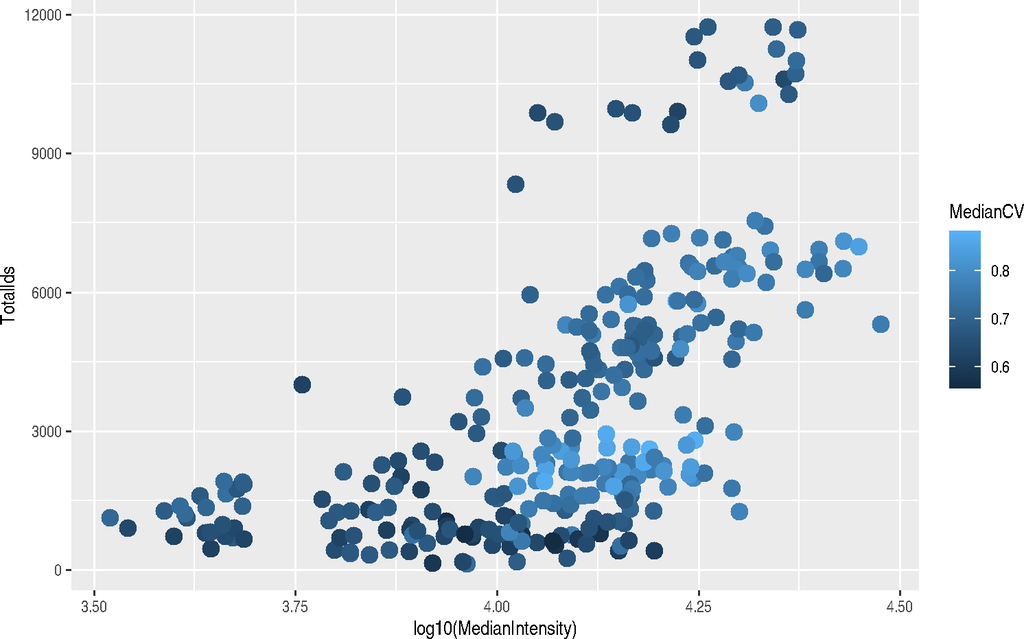

```r
  colData(acms) |>
    data.frame() |>
    ggplot(aes(x = log10(MedianIntensity),
               y = TotalIds,
               colour = MedianCV)) +
    geom_point(size = 4)
```

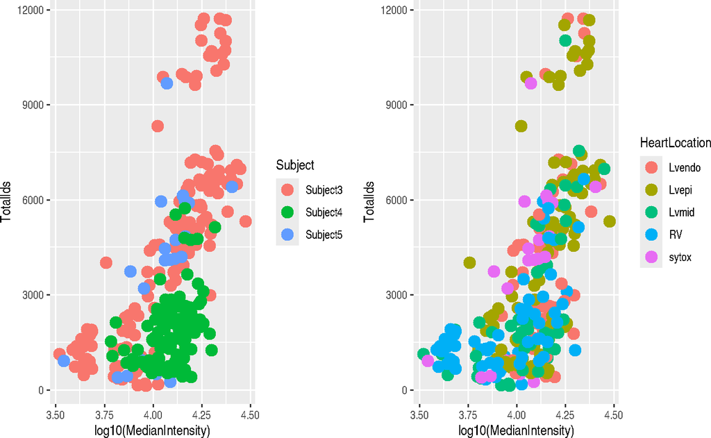

```r
colData(acms) |>
    data.frame() |>
    ggplot(aes(x = log10(MedianIntensity),
               y = TotalIds,
               colour = Subject)) +
    geom_point(size = 4) +
    colData(acms) |>
    data.frame() |>
    ggplot(aes(x = log10(MedianIntensity),
               y = TotalIds,
               colour = HeartLocation)) +
    geom_point(size = 4)
```

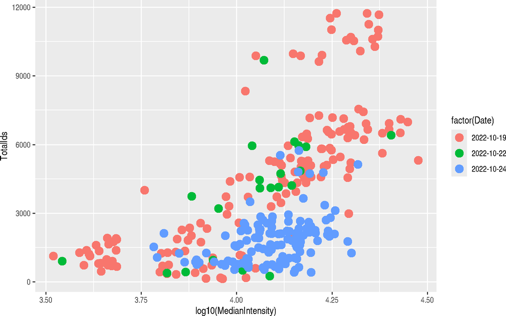

```r
  colData(acms) |>
    data.frame() |>
    ggplot(aes(x = log10(MedianIntensity),
               y = TotalIds,
               colour = factor(Date))) +
    geom_point(size = 4)
```

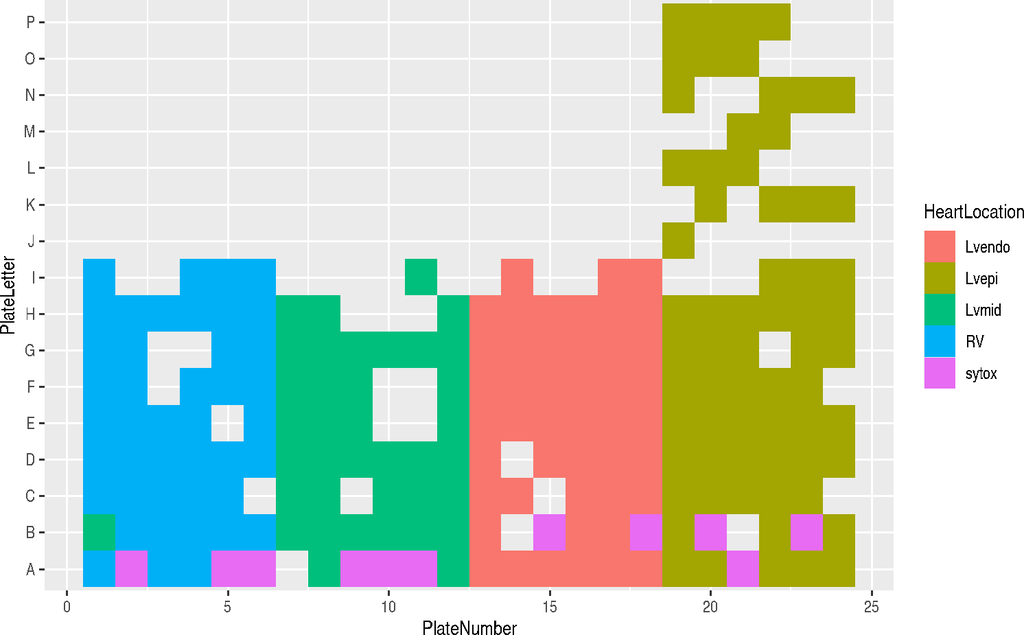

```r
colData(acms) |>
    data.frame() |>
    mutate(PlateNumber = as.numeric(substr(PlateWell, 2, 3))) |>
    ggplot(aes(x = PlateNumber,
               y = PlateLetter,
               fill = HeartLocation)) +
    geom_tile()
```

# 5 Data processing

We start by log-transforming our data for downstream statistical analyses. The `logTransfrorm()` function will create a new assay, named `precursors_log`.

```r
(acms <- logTransform(acms, "precursors", "precursors_log"))
```

```
## An instance of class QFeatures containing 301 set(s):
##  [1] 221019_CM_SUBJECT-03_CMs_Subject3_Lvendo_A13_BA14_1_7445.d: SingleCellExperiment with 6634 rows and 1 columns
##  [2] 221019_CM_SUBJECT-03_CMs_Subject3_Lvendo_A14_BA15_1_7446.d: SingleCellExperiment with 4326 rows and 1 columns
##  [3] 221019_CM_SUBJECT-03_CMs_Subject3_Lvendo_A15_BA16_1_7447.d: SingleCellExperiment with 6263 rows and 1 columns
##  ...
##  [299] 221024_Subject-04_CMs_Subject4_D_RV_I1_BI11_1_7861.d: SingleCellExperiment with 858 rows and 1 columns
##  [300] precursors: SingleCellExperiment with 12731 rows and 299 columns
##  [301] precursors_log: SingleCellExperiment with 12731 rows and 299 columns
```

While we will be performing our analyses with precursor data, below we show how to aggregate these data into peptide and protein data.

```r
acms <- aggregateFeatures(acms,
                          i = "precursors_log",
                          name = "peptides",
                          fcol = "Modified.Sequence",
                          fun = colMedians,
                          na.rm = TRUE)
```

```
## Your quantitative data contain missing values. Please read the relevant
## section(s) in the aggregateFeatures manual page regarding the effects
## of missing values on data aggregation.
```

```r
acms[["peptides"]]
```

```
## class: SingleCellExperiment
## dim: 11115 299
## metadata(0):
## assays(2): assay aggcounts
## rownames(11115): AAAEDVNVTFEDQQK AAAEELLAR ... YYTVFDR YYVTIIDAPGHR
## rowData names(12): Protein.Group Protein.Ids ... Lib.PG.Q.Value .n
## colnames(299):
##   X:\TimsTOF-SCP\Data\CM_PROJECT\221019_CM_SUBJECT-03\CMs_Subject3_Lvendo_A13_BA14_1_7445.d
##   X:\TimsTOF-SCP\Data\CM_PROJECT\221019_CM_SUBJECT-03\CMs_Subject3_Lvendo_A14_BA15_1_7446.d
##   ...
##   X:\TimsTOF-SCP\Data\CM_PROJECT\221024_Subject-04\CMs_Subject4_D_RV_H4_BH7_1_7858.d
##   X:\TimsTOF-SCP\Data\CM_PROJECT\221024_Subject-04\CMs_Subject4_D_RV_I1_BI11_1_7861.d
## colData names(0):
## reducedDimNames(0):
## mainExpName: NULL
## altExpNames(0):
```

```r
acms <- aggregateFeatures(acms,
                          i = "peptides",
                          name = "proteins",
                          fcol = "Protein.Ids",
                          fun = colMedians,
                          na.rm = TRUE)
```

```
## Your quantitative data contain missing values. Please read the relevant
## section(s) in the aggregateFeatures manual page regarding the effects
## of missing values on data aggregation.
```

```r
acms[["peptides"]]
```

```
## class: SingleCellExperiment
## dim: 11115 299
## metadata(0):
## assays(2): assay aggcounts
## rownames(11115): AAAEDVNVTFEDQQK AAAEELLAR ... YYTVFDR YYVTIIDAPGHR
## rowData names(12): Protein.Group Protein.Ids ... Lib.PG.Q.Value .n
## colnames(299):
##   X:\TimsTOF-SCP\Data\CM_PROJECT\221019_CM_SUBJECT-03\CMs_Subject3_Lvendo_A13_BA14_1_7445.d
##   X:\TimsTOF-SCP\Data\CM_PROJECT\221019_CM_SUBJECT-03\CMs_Subject3_Lvendo_A14_BA15_1_7446.d
##   ...
##   X:\TimsTOF-SCP\Data\CM_PROJECT\221024_Subject-04\CMs_Subject4_D_RV_H4_BH7_1_7858.d
##   X:\TimsTOF-SCP\Data\CM_PROJECT\221024_Subject-04\CMs_Subject4_D_RV_I1_BI11_1_7861.d
## colData names(0):
## reducedDimNames(0):
## mainExpName: NULL
## altExpNames(0):
```

# 6 Statistical modelling

We will model the data following the *scplainer* pipeline (Vanderaa and Gatto 2024).

## 6.1 Modelling

We extract the log-transformed precursor assez and remove sytox cells (all from subject 5):

```r
sce <- getWithColData(acms, "precursors_log")
sce <- sce[, sce$HeartLocation != "sytox"]
```

```r
sce <- scpModelWorkflow(
    sce,
    formula = ~ 1 + ## intercept
        ## normalisation
        MedianIntensity +
        ## batch effects
        PlateLetter +
        Subject +
        ## biological variability
        HeartLocation
)
```

Here, we define the missing data filtering threshold: we want at least 3 measurement for each coefficient estimation.

```
## To change the threshold, use:
## scpModelFilterThreshold(object, name) <- threshold
```

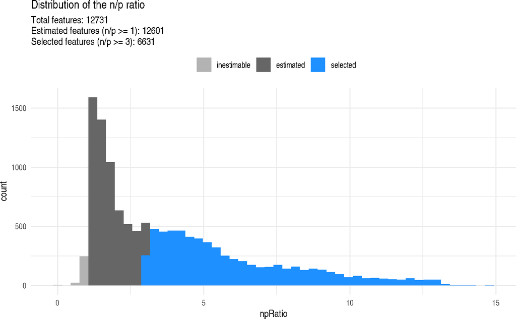

```r
scpModelFilterThreshold(sce) <- 3
scpModelFilterPlot(sce)
```

```
## To change the threshold, use:
## scpModelFilterThreshold(object, name) <- threshold
```

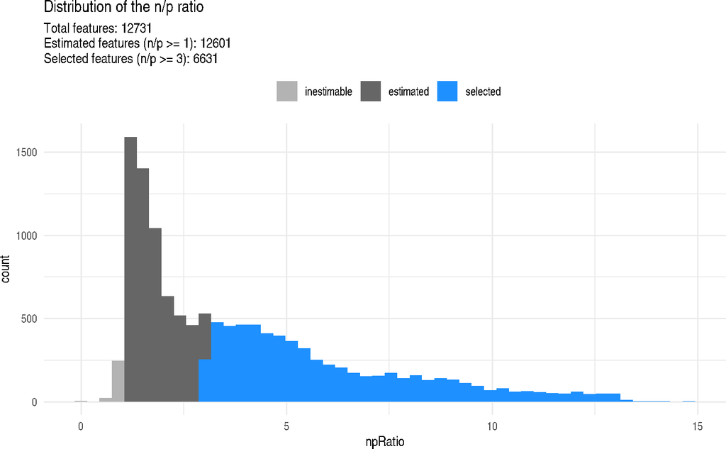

```r
scpModelFilterPlot(sce)
```

## 6.2 Analysis of variance

```r
(vaRes <- scpVarianceAnalysis(sce))
```

```
## DataFrameList of length 5
## names(5): Residuals MedianIntensity PlateLetter Subject HeartLocation
```

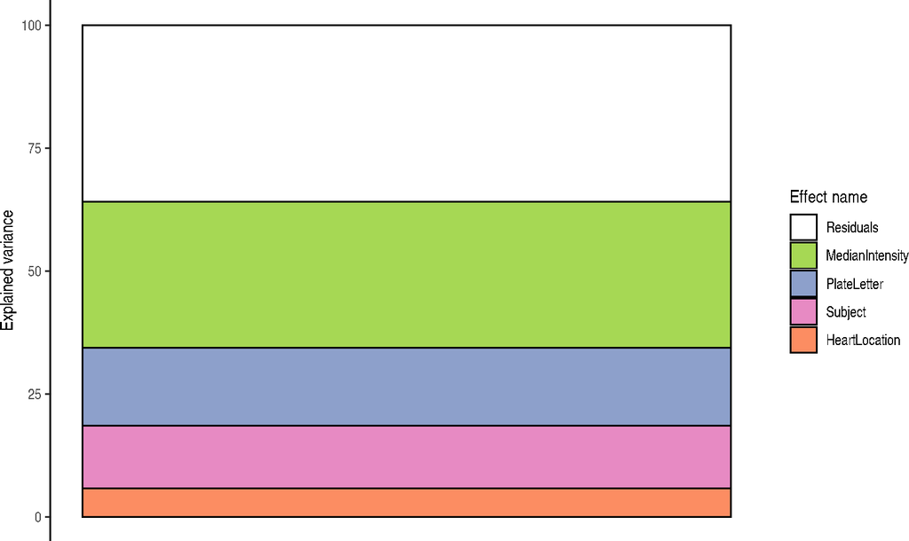

```r
## Add annotations from the rowData()
vaRes <- scpAnnotateResults(
    vaRes, rowData(sce), by = "feature", by2 = "Precursor.Id"
)

scpVariancePlot(vaRes)
```

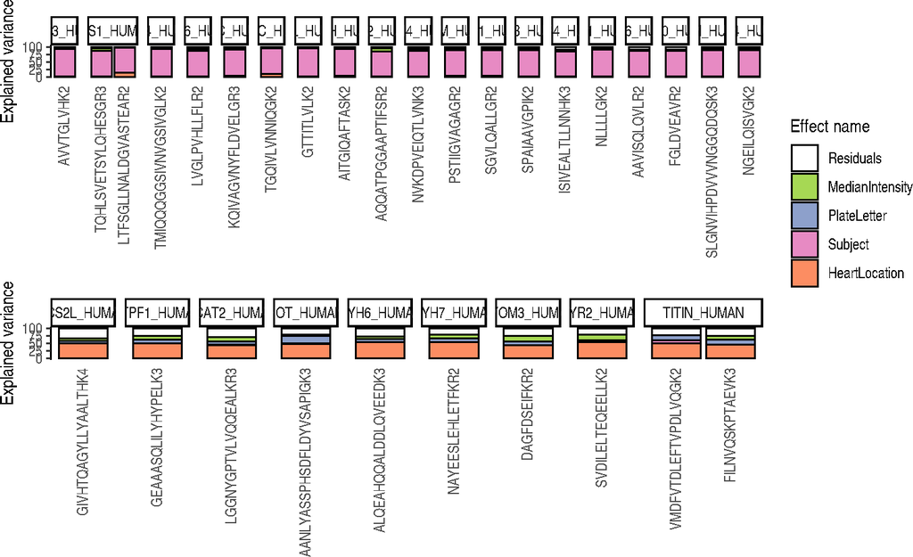

```r
## Two figures on one plot
scpVariancePlot(
    vaRes, top = 20, by = "percentExplainedVar", effect = "Subject",
    decreasing = TRUE, combined = FALSE, fcol = "Protein.Names"
) + scpVariancePlot(
        vaRes, top = 10, by = "percentExplainedVar", effect = "HeartLocation",
        decreasing = TRUE, combined = FALSE, fcol = "Protein.Names"
    ) + plot_layout(ncol = 1, guides = "collect")
```

## 6.3 Differential abundance analysis

```r
locations <- unique(sce$HeartLocation)
combinations <- combn(locations, 2)
contrasts <- lapply(1:ncol(combinations),
                    function(i) c("HeartLocation",
                                  combinations[, i]))

(daRes <- scpDifferentialAnalysis(
     sce, contrast = contrasts
 ))
```

```
## DataFrameList of length 6
## names(6): HeartLocation_Lvendo_vs_Lvepi ... HeartLocation_Lvmid_vs_RV
```

```r
daRes[[1]]
```

[output not shown]

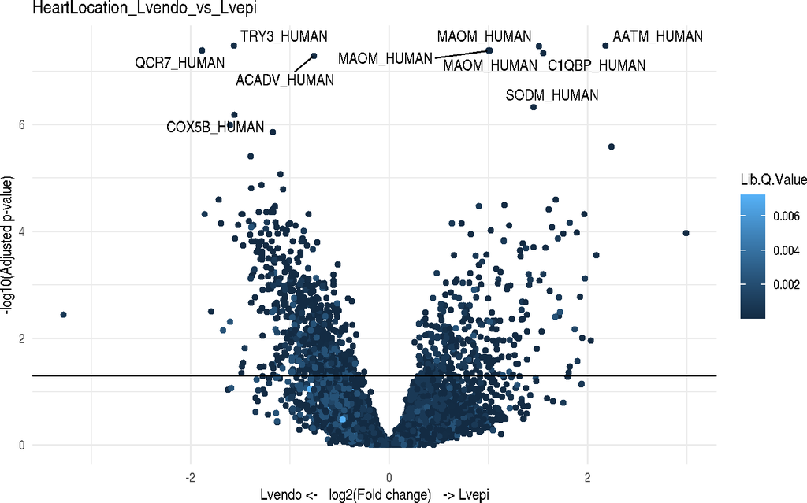

```r
daRes <-
    scpAnnotateResults(
        daRes, rowData(sce),
        by = "feature", by2 = "Precursor.Id")

scpVolcanoPlot(daRes,
               textBy = "Protein.Names",
               pointParams = list(aes(colour = Lib.Q.Value)))[[1]]
```

## 6.4 Component analysis

```r
(caRes <- scpComponentAnalysis(
     sce, ncomp = 15, method = "APCA"))
```

```
## List of length 2
## names(2): bySample byFeature
```

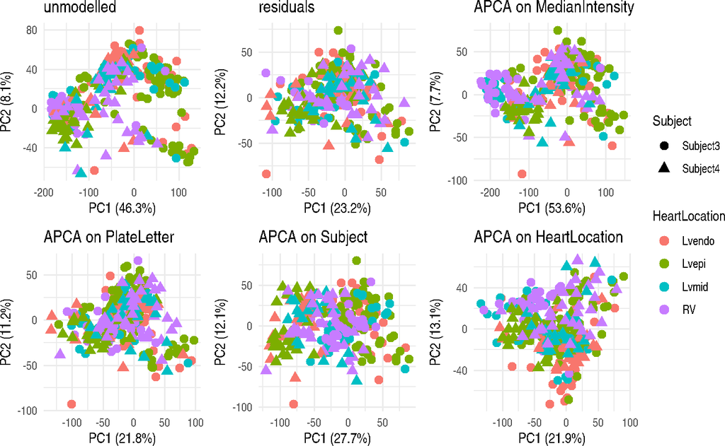

```r
caResCells <- caRes$bySample
sce$cell <- colnames(sce)
caResCells <- scpAnnotateResults(caResCells,
                                 colData(sce), by = "cell")


scpComponentPlot(
    caResCells,
    pointParams = list(aes(colour = HeartLocation,
                           shape = Subject),
                       size = 3)) |>
    wrap_plots() +
    plot_layout(guides = "collect")
```

```r
library(scater)
```

[figure not shown]

```r
sce <-addReducedDims(sce, caRes$bySample)
sce <- runTSNE(sce, dimred = "APCA_HeartLocation")

plotTSNE(sce, colour_by = "HeartLocation") +
    plotTSNE(sce, colour_by = "Subject") +
    plotTSNE(sce, colour_by = "PlateLetter") +
    plotTSNE(sce, colour_by = "MedianIntensity")
```

We can not extract the hear location effect matrix, removing the subject, plate position and median intensity effects for downstream analysis.

```r
scebr <- scpRemoveBatchEffect(
  sce, effects = c("Subject", "PlateLetter", "MedianIntensity"),
  intercept = TRUE)
```

# 7 Downstream analyses

# 8 Session information

This vignette pas prepared as part of the [EuBIC 2025 developer hackathon](https://eubic-ms.org/events/2025-developers-meeting/).

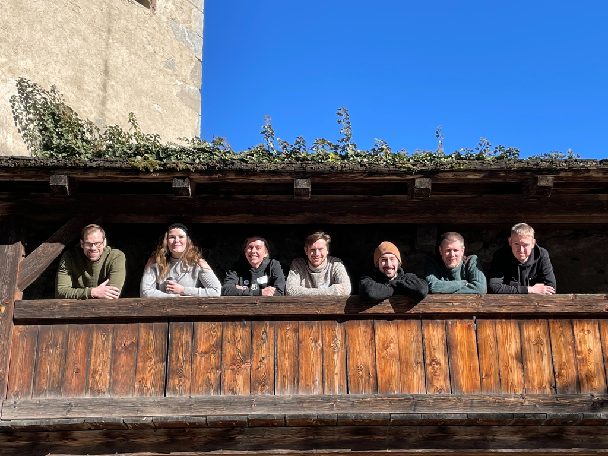

# References

Ai, Lizhuo, Aleksandra Binek, Vladimir Zhemkov, Jae Hyung Cho, Ali Haghani, Simion Kreimer, Edo Israely, et al. 2025. “Single Cell Proteomics Reveals Specific Cellular Subtypes in Cardiomyocytes Derived from Human iPSCs and Adult Hearts.” *Mol. Cell. Proteomics*, no. 100910 (January): 100910. https://doi.org/10.1016/j.mcpro.2025.100910.

Vanderaa, Christophe, and Laurent Gatto. 2024. “scplainer: Using Linear Models to Understand Mass Spectrometry-Based Single-Cell Proteomics Data.” *bioRxiv*. https://doi.org/10.1101/2023.12.14.571792.